# Smarphone_recommendation_system

**Table of Contents :**

- Importing Libraries
- Loading data files
- Perform basic EDA

  ```
  a.Data type of each attribute
  b.5 point summary of numerical attributes
  c.Checking the presence of missing values
  d.Rounding oﬀ scores to the nearest integers
  e.Shape of the data
  f.Drop Unneccessary attributes
  ```

- Create subset of the original dataset
  - authors who gave greater than 50 ratings
  - product that got more than 50 ratings -Unique Users and Products Count
- Data Analysis and Visualization

  ```
  a. Score Distribution

      Observations
      Observations

  b. Top Rating Count Distribution grouped by Products

      Observations
  ```

- Recommender Systems

  ```
  a. Popularity Based Recommender Model
  b. Collaborative Filtering Recommender Model using SURPRISE Library
  ```

- Split the data into training and test set in the ratio of 70:30 respectively

  KNN With Means - Memory Based Collaborative Filtering Find optimal model using RandomizedSearchCV

  ```
      Initialize
      Fit and Predict
      Cross Validate
      Recommend
      Observations
  ```

  SVD- Model Based Collaborative Filtering

  ```
   Find optimal model using RandomizedSearchCV
      Initialize
      Fit and Predict
      Cross Validate
      Recommend
      Observations
  ```

- Conclusion

  ```
    Popularity Based Recommendation Model

    Collaborative Filtering Recommendation Model

      KNNWithMeans Model
      SVD Model
  ```

**Importing Libraries**

```python
import warnings
warnings.filterwarnings('ignore')
import numpy as np
import pandas as pd
import matplotlib.pyplot as plt
import seaborn as sns
sns.set_color_codes()
sns.set(style="whitegrid")
%matplotlib inline
from sklearn import metrics
from sklearn.model_selection import train_test_split
from sklearn.metrics import mean_squared_error
from math import sqrt

# surprise Library neccessary for Collaborative filtering Method

from surprise import accuracy
from surprise.model_selection.validation import cross_validate
from surprise.dataset import Dataset
from surprise.reader import Reader
from surprise import SVD
from surprise import KNNWithMeans
```

**Loading data files:**

```python
data1=pd.read_csv("/phone_user_review_file_1.csv",encoding='iso-8859-1')
data2=pd.read_csv("/phone_user_review_file_2.csv",encoding='iso-8859-1')
data3=pd.read_csv("/phone_user_review_file_3.csv",encoding='iso-8859-1')
data4=pd.read_csv("/phone_user_review_file_4.csv",encoding='iso-8859-1')
data5=pd.read_csv("/phone_user_review_file_5.csv",encoding='iso-8859-1')
data6=pd.read_csv("/phone_user_review_file_6.csv",encoding='iso-8859-1')
```

```python
 data=pd.concat([data1, data2, data3, data4, data5, data6],axis=0)
 data.head().T
```

|  | 0 | 1 | 2 | 3 | 4 |
| --- | --- | --- | --- | --- | --- |
| phone_url | /cellphones/samsung-galaxy-s8/ | /cellphones/samsung-galaxy-s8/ | /cellphones/samsung-galaxy-s8/ | /cellphones/samsung-galaxy-s8/ | /cellphones/samsung-galaxy-s8/ |
| date | 5/2/2017 | 4/28/2017 | 5/4/2017 | 5/2/2017 | 5/11/2017 |
| lang | en | en | en | en | en |
| country | us | us | us | us | us |
| source | Verizon Wireless | Phone Arena | Amazon | Samsung | Verizon Wireless |
| domain | verizonwireless.com | phonearena.com | amazon.com | samsung.com | verizonwireless.com |
| score | 10 | 10 | 6 | 9.2 | 4 |
| score_max | 10 | 10 | 10 | 10 | 10 |
| extract | As a diehard Samsung fan who has had every Sam... | Love the phone. the phone is sleek and smooth ... | Adequate feel. Nice heft. Processor's still sl... | Never disappointed. One of the reasons I've be... | I've now found that i'm in a group of people t... |
| author | CarolAnn35 | james0923 | R. Craig | Buster2020 | S Ate Mine |
| product | Samsung Galaxy S8 | Samsung Galaxy S8 | Samsung Galaxy S8 (64GB) G950U 5.8" 4G LTE Unl... | Samsung Galaxy S8 64GB (AT&T) | Samsung Galaxy S8 |

**Perform basic EDA :**

```python
df = data.copy()
```

a.Data type of each attribute

```python
df.info()
```

```
<class 'pandas.core.frame.DataFrame'>
Int64Index: 1415133 entries, 0 to 163836
Data columns (total 11 columns):
 #   Column     Non-Null Count    Dtype
---  ------     --------------    -----
 0   phone_url  1415133 non-null  object
 1   date       1415133 non-null  object
 2   lang       1415133 non-null  object
 3   country    1415133 non-null  object
 4   source     1415133 non-null  object
 5   domain     1415133 non-null  object
 6   score      1351644 non-null  float64
 7   score_max  1351644 non-null  float64
 8   extract    1395772 non-null  object
 9   author     1351931 non-null  object
 10  product    1415132 non-null  object
dtypes: float64(2), object(9)
memory usage: 129.6+ MB
```

b. 5 point summary of numerical attributes

```python
df.describe()
```

|  | score | score_max |
| --- | --- | --- |
| count | 1.351644e+06 | 1351644.0 |
| mean | 8.007060e+00 | 10.0 |
| std | 2.616121e+00 | 0.0 |
| min | 2.000000e-01 | 10.0 |
| 25% | 7.200000e+00 | 10.0 |
| 50% | 9.200000e+00 | 10.0 |
| 75% | 1.000000e+01 | 10.0 |
| max | 1.000000e+01 | 10.0 |

c.Checking the presence of missing values

```python
df.isnull().sum()
```

```
phone_url        0
date             0
lang             0
country          0
source           0
domain           0
score        63489
score_max    63489
extract      19361
author       63202
product          1
dtype: int64
```

```python
# Imputing the missing values by filling the null values in column 'score' and 'score_max'
df = df.fillna(df.median())

# dropping the null values in columns 'extract' ,'author' and 'product'
df = df.dropna()
```

```python
# Rounding oﬀ scores to the nearest integers.
df['score'] = df['score'].astype(int)
df['score_max'] = df['score_max'].astype(int)
```

e.Shape of the data

```python
df.shape
```

```
(1336416, 11)
```

```python
# Checking for duplicate values and remove them if there is any.
df_NoDup = df.drop_duplicates()
```

f. Drop unneccessary attribute

```python
# Dropping all unuseful features
df_NoDup.drop(['phone_url','date','lang','country','source','domain','score_max','extract'], axis = 1, inplace = True)
```

```python
df_NoDup_Copy = df_NoDup.copy()
```

```python
print(df_NoDup.shape)
df_NoDup.info()
```

```
(1331600, 3)
<class 'pandas.core.frame.DataFrame'>
Int64Index: 1331600 entries, 0 to 163836
Data columns (total 3 columns):
 #   Column   Non-Null Count    Dtype
---  ------   --------------    -----
 0   score    1331600 non-null  int64
 1   author   1331600 non-null  object
 2   product  1331600 non-null  object
dtypes: int64(1), object(2)
memory usage: 40.6+ MB
```

```python
# Keeping 1000000 samples (Using random state=612 as mentioned in procedure)
df = df_NoDup.sample(n=1000000, random_state=612)
```

```python
# Identifying most rated features.
# sorting on products that got highest mean score
df.groupby('product')['score'].mean().sort_values(ascending=False).head()
```

```
product
Nokia 5310 Xpress Music, sakura red sim-free unbranded kein Vertrag    10.0
Oppo Find 5 X909 16 Gb White Ð¡Ð¼Ð°ÑÑÑÐ¾Ð½                          10.0
Sony Ericsson W880i Prepay Mobile Phone On Orange                      10.0
Huawei Mobiltelefoner Mate 8 Dual SIM 32GB                             10.0
Huawei NOVA 4G MYSTIC SILVER                                           10.0
Name: score, dtype: float64
```

```python
# Identifying users with most number of reviews
(df['author'].value_counts()).head()
```

```
Amazon Customer    57765
Cliente Amazon     14564
e-bit               6309
Client d'Amazon     5720
Amazon Kunde        3624
Name: author, dtype: int64
```

```python
# The product that got most number of reviews.
df['product'].value_counts().head()
```

```
Lenovo Vibe K4 Note (White,16GB)     3908
Lenovo Vibe K4 Note (Black, 16GB)    3234
OnePlus 3 (Graphite, 64 GB)          3128
OnePlus 3 (Soft Gold, 64 GB)         2643
Huawei P8lite zwart / 16 GB          1994
Name: product, dtype: int64
```

**Create subset of the original dataset**

```python
# extracting authors who gave greater than 50 ratings
df_auther_rating = pd.DataFrame(columns=['author', 'authorrating_count'])
df_auther_rating['author']=df['author'].value_counts().index.tolist()
df_auther_rating['authorrating_count'] = list(df['author'].value_counts() > 50)
# get names of indexes for which count column value is False
index_names = df_auther_rating[ df_auther_rating['authorrating_count'] == False ].index
# drop these row indexes from dataFrame
df_auther_rating.drop(index_names, inplace = True)
df_auther_rating
```

|  | author | authorrating_count |
| --- | --- | --- |
| 0 | Amazon Customer | True |
| 1 | Cliente Amazon | True |
| 2 | e-bit | True |
| 3 | Client d'Amazon | True |
| 4 | Amazon Kunde | True |
| ... | ... | ... |
| 674 | Carla | True |
| 675 | Ganesh | True |
| 676 | cemdiler | True |
| 677 | elena | True |
| 678 | Ralf | True |

679 rows × 2 columns

```python
# extracting product that got more than 50 ratings
df_product_rating = pd.DataFrame(columns=['product', 'productrating_count'])
df_product_rating['product']=df['product'].value_counts().index.tolist()
df_product_rating['productrating_count'] = list(df['product'].value_counts() > 50)
# get names of indexes for which count column value is False
index_names = df_product_rating[ df_product_rating['productrating_count'] == False ].index
# drop these row indexes from dataFrame
df_product_rating.drop(index_names, inplace = True)
df_product_rating
```

|  | product | productrating_count |
| --- | --- | --- |
| 0 | Lenovo Vibe K4 Note (White,16GB) | True |
| 1 | Lenovo Vibe K4 Note (Black, 16GB) | True |
| 2 | OnePlus 3 (Graphite, 64 GB) | True |
| 3 | OnePlus 3 (Soft Gold, 64 GB) | True |
| 4 | Huawei P8lite zwart / 16 GB | True |
| ... | ... | ... |
| 4341 | Apple iPhone 6S 16GB | True |
| 4342 | LG Spirit H420 Smartphone, Bianco [Italia] | True |
| 4343 | Tracfone LG 306G with 600 Minutes and Triple M... | True |
| 4344 | Microsoft Nokia 5140i schwarz (GSM, VGA-Kamera... | True |
| 4345 | Nokia Lumia 830 GSM Smartphone, Black - AT&T -... | True |

4346 rows × 2 columns

```python
# selecting data rows where product is having more than 50 ratings.
df_product_data = df[df['product'].isin(df_product_rating['product'])]
df_product_data
```

|  | score | author | product |
| --- | --- | --- | --- |
| 104246 | 10 | Paul B | Samsung i897 Captivate Android Smartphone Gala... |
| 78693 | 10 | Yuvraj | Blu Win JR LTE (Grey, 4GB) |
| 8816 | 2 | Joyce D. Pratt | BLU Vivo XL Smartphone - 5.5" 4G LTE - GSM Unl... |
| 116623 | 10 | David B | Samsung S3350 Chat 335 Sim Free Mobile Phone |
| 35333 | 10 | Sebastian | Samsung E1190 Handy (3,6 cm (1,43 Zoll) Displa... |
| ... | ... | ... | ... |
| 87173 | 8 | Javier | Huawei Ascend Y330 - Smartphone libre Android ... |
| 281625 | 8 | Patrix | Huawei Ascend G510 Smartphone Touch, Fotocamer... |
| 110881 | 2 | Amazon Customer | Apple iPhone 5C Factory Unlocked Cellphone, 8G... |
| 36197 | 10 | majere1975 | Samsung Smartphone Galaxy S Advance, Display 4... |
| 99081 | 10 | ALBERT M. MASSILLON | BLU Dash JR K Smartphone - Unlocked - Black |

558101 rows × 3 columns

```python
# selecting data rows from df_byproductdata where author has given more than 50 ratings.
dataset = df_product_data[df_product_data['author'].isin(df_auther_rating['author'])]
dataset
```

|  | score | author | product |
| --- | --- | --- | --- |
| 35333 | 10 | Sebastian | Samsung E1190 Handy (3,6 cm (1,43 Zoll) Displa... |
| 290678 | 8 | sara | Samsung SM-N910F Galaxy Note 4 Smartphone, 32 ... |
| 101404 | 10 | ÐÐ²Ð³ÐµÐ½Ð¸Ð¹ | Sony Xperia Z1 Compact (Ð»Ð°Ð¹Ð¼) |
| 223332 | 8 | Amazon Customer | Motorola Moto G 3rd Generation SIM-Free Smartp... |
| 361379 | 10 | e-bit | Smartphone Motorola Moto G 4 Play XT1603 |
| ... | ... | ... | ... |
| 21110 | 2 | Amazon customer | Tracfone Motorola Moto E Android Prepaid Phone... |
| 321740 | 8 | Qantas | Sony Ericsson K810i Cyber-shot |
| 269553 | 9 | Capyto | Samsung M150 Cep Telefonu |
| 87173 | 8 | Javier | Huawei Ascend Y330 - Smartphone libre Android ... |
| 110881 | 2 | Amazon Customer | Apple iPhone 5C Factory Unlocked Cellphone, 8G... |

108983 rows × 3 columns

```python
# FinalDataset

print(dataset.shape)
```

```
(108983, 3)
```

g. Unique authors and Products Count

```python
print('Total unique authors in the dataset', dataset['author'].nunique())
print('Total unique products in the dataset', dataset['product'].nunique())
```

```
Total unique authors in the dataset 677
Total unique products in the dataset 3987
```

**Data Analysis and Visualization**

a. Score Distribution

```python
def distplot(figRows,figCols,xSize, ySize, data, features, colors, kde=True, bins=None):
    f, axes = plt.subplots(figRows, figCols, figsize=(xSize, ySize))

    features = np.array(features).reshape(figRows, figCols)
    colors = np.array(colors).reshape(figRows, figCols)

    for row in range(figRows):
        for col in range(figCols):
            if (figRows == 1 and figCols == 1) :
                axesplt = axes
            elif (figRows == 1 and figCols > 1) :
                axesplt = axes[col]
            elif (figRows > 1 and figCols == 1) :
                axesplt = axes[row]
            else:
                axesplt = axes[row][col]
            plot = sns.distplot(data[features[row][col]], color=colors[row][col], bins=bins, ax=axesplt, kde=kde, hist_kws={"edgecolor":"k"})
            plot.set_xlabel(features[row][col],fontsize=20)
```

```python
pal = sns.color_palette(palette='Set1', n_colors=16)
```

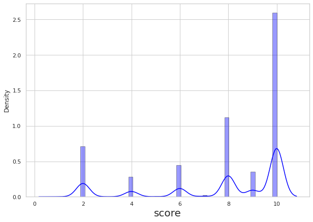

```python
distplot(1, 1, 10, 7, data=dataset, features=['score'], colors=['blue'])
```

Observations:

- Many users have rated 10 as it is shown with the huge spike.
- This is followed by rating 8 which also has high number
- Ratings 2,4,6,9 are comparatively less.

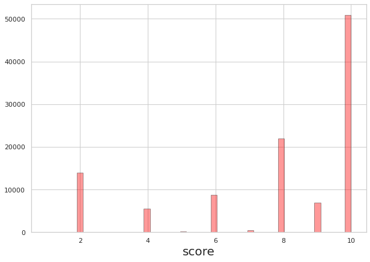

```python
distplot(1, 1, 10, 7, data=dataset, features=['score'], colors=['red'], kde=False)
```

b. Top Rating Count Distribution grouped by Products

```python
electronics_groupby_products_Ratings = dataset.groupby('product')['score']
```

```python
electronics_groupby_products_Ratings.count().clip(upper=30).unique()
```

```
array([ 1,  4, 24, 19, 30, 20, 27,  7, 16, 23,  6, 10, 14, 22, 25, 12,  8,
        9, 15, 18,  3, 11,  2, 26, 28, 17, 13,  5, 21, 29])
```

```python
ratings_products = pd.DataFrame(electronics_groupby_products_Ratings.count().clip(upper=30))
ratings_products.rename(columns={"score": "Rating_Count"}, inplace=True)
```

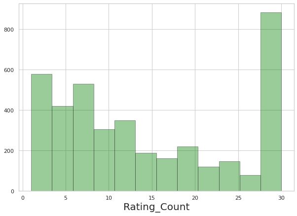

```python
distplot(1, 1, 10, 7, data=ratings_products, features=['Rating_Count'], colors=['green'], kde=False)
```

Observations:

This is a ratings count distribution grouped by all the Products. For the plot perspective, I have clipped the upper limit to 30 which means any value above 30 will be set to it.

# a. Popularity Based Recommender Model:

Popularity based recommendation system uses the items that are in trend right now. It ranks products based on its popularity i.e. the rating count. If a product is highly rated then it is most likely to be ranked higher and hence will be recommended. As it is based on the products popularity, this can not be personalized and hence same set of products will be recommended for all the users.

```python
#calculating the mean score for a product by grouping it.
ratings_mean_count = pd.DataFrame(dataset.groupby('product')['score'].mean())
# calculating the number of ratings a product got
ratings_mean_count['rating_counts'] = pd.DataFrame(dataset.groupby('product')['score'].count())
# Recommending the 5 mobile phones based in highest mean score and highest number of ratings the product got.
ratings_mean_count.sort_values(by=['score','rating_counts'], ascending=[False,False]).head()
```

| product | score | rating_counts |
| --- | --- | --- |
| Samsung Galaxy Note5 | 10.0 | 56 |
| Samsung Galaxy S7 Edge 32Gb | 10.0 | 13 |
| Sim Free Apple iPhone SE 64GB Mobile Phone - Space Grey | 10.0 | 12 |
| BlackBerry Z30 Factory Unlocked Black - 16GB | 10.0 | 8 |
| Huawei Ascend Mate 7 Smartphone (6 Zoll (15,2 cm) Touch-Display, 16 GB Speicher, Android 4.4 ) obsidian black | 10.0 | 8 |

**b. Collaborative Filtering Recommender Model using SURPRISE Library**

Collaborative filtering is a method of making predictions about the interests of user by analysing the taste of users which are similar to the said user. The idea of filtering patterns by collaborating multiple viewpoints is why it is called collaborative filtering.

```python
reader = Reader(rating_scale=(1, 10))
surprise_data = Dataset.load_from_df(dataset[['author', 'product', 'score']], reader)
```

Split the data into training and test set in the ratio of 70:30 respectively

```python
from surprise.model_selection import train_test_split
trainset, testset = train_test_split(surprise_data, test_size=.3, random_state=10)
```

```python
from collections import defaultdict

def get_top_n(predictions, n=10):
    # First map the predictions to each author.
    top_n = defaultdict(list)
    for uid, iid, true_r, est, _ in predictions:
        top_n[uid].append((iid, est))

    # Then sort the predictions for each author and retrieve the k highest ones.
    for uid, user_ratings in top_n.items():
        user_ratings.sort(key=lambda x: x[1], reverse=True)
        top_n[uid] = user_ratings[:n]

    return top_n
```

```python
class collab_filtering_based_recommender_model():
    def __init__(self, model, trainset, testset, data):
        self.model = model
        self.trainset = trainset
        self.testset = testset
        self.data = data
        self.pred_test = None
        self.recommendations = None
        self.top_n = None
        self.recommenddf = None

#Function for model fitting and calculating rmse

    def fit_and_predict(self):
        self.model.fit(self.trainset)
        self.pred_test = self.model.test(self.testset)
        rmse = round(accuracy.rmse(self.pred_test), 3)
        self.top_n = get_top_n(self.pred_test)
        self.recommenddf = pd.DataFrame(columns=['Author', 'product', 'Score'])
        for item in self.top_n:
            subdf = pd.DataFrame(self.top_n[item], columns=['product', 'Score'])
            subdf['Author'] = item
            cols = subdf.columns.tolist()
            cols = cols[-1:] + cols[:-1]
            subdf = subdf[cols]
            self.recommenddf = pd.concat([self.recommenddf, subdf], axis = 0)
        return rmse

#Function for cross validation

    def cross_validate(self):
        cv_result = cross_validate(self.model, self.data,n_jobs=-1)
        cv_result = round(cv_result['test_rmse'].mean(),3)
        return cv_result

#Function for checking recommendation

    def recommend(self, user_id, n=5):
        df = self.recommenddf[self.recommenddf['Author'] == user_id].head(n)
        display(df)
        return df
```

```python
from surprise.model_selection import RandomizedSearchCV

def find_best_model(model, parameters,data):
    clf = RandomizedSearchCV(model, parameters, n_jobs=-1, measures=['rmse'])
    clf.fit(data)
    print(clf.best_score)
    print(clf.best_params)
    print(clf.best_estimator)
    return clf
```

User-User Collaborative Filtering

To find the rating R that a user U would give to an item I, the approach includes:

Finding users similar to U who have rated the item I Calculating the rating R based the score of users found in the previous step Here we are using KNN with means to remove the bias by taking into account the mean ratings of each user.

Find optimal model using RandomizedSearchCV

```python
sim_options = {
    "name": ["msd", "cosine", "pearson", "pearson_baseline"],
    "min_support": [3, 4, 5],
    "user_based": [True],
}
params = { 'k': range(30,50,1), 'sim_options': sim_options}
clf = find_best_model(KNNWithMeans, params, surprise_data)
```

```
{'rmse': 2.6546878629596007}
{'rmse': {'k': 38, 'sim_options': {'name': 'cosine', 'min_support': 3, 'user_based': True}}}
{'rmse': <surprise.prediction_algorithms.knns.KNNWithMeans object at 0x7f7b8d2fdd90>}
```

Initialize

```python
knnwithmeans = clf.best_estimator['rmse']
col_fil_knnwithmeans = collab_filtering_based_recommender_model(knnwithmeans, trainset, testset, surprise_data)
```

Fit and Predict

```python
knnwithmeans_rmse = col_fil_knnwithmeans.fit_and_predict()
```

```
Computing the cosine similarity matrix...
Done computing similarity matrix.
RMSE: 2.6769
```

Cross Validate

```python
knnwithmeans_cv_rmse = col_fil_knnwithmeans.cross_validate()
knnwithmeans_cv_rmse
```

```
2.658
```

Recommend

```python
result_knn_user1 = col_fil_knnwithmeans.recommend(user_id='Dennis', n=5)
print("--------------------------------------------------------------------------")
result_knn_user2 = col_fil_knnwithmeans.recommend(user_id='Claudia', n=5)
print("--------------------------------------------------------------------------")
result_knn_user3 = col_fil_knnwithmeans.recommend(user_id='Rick', n=5)
```

|  | Author | product | Score |
| --- | --- | --- | --- |
| 0 | Dennis | Lenovo Motorola Moto G Smartphone (11,4 cm (4,... | 10.000000 |
| 1 | Dennis | Huawei Ascend G7 Smartphone, 16 GB, Argento | 10.000000 |
| 2 | Dennis | Samsung Galaxy A5 (2017) zwart / 32 GB | 9.515883 |
| 3 | Dennis | Samsung Galaxy S3 I535 16GB Verizon Wireless 4... | 9.121073 |
| 4 | Dennis | Samsung Galaxy S3 I535 16GB Verizon Wireless 4... | 9.121073 |

|  | Author | product | Score |
| --- | --- | --- | --- |
| 0 | Claudia | Samsung SGH-T989 Galaxy S II 16GB White Androi... | 10.000000 |
| 1 | Claudia | Lenovo Motorola Moto G 8 GB - Smartphone libre... | 9.662580 |
| 2 | Claudia | Huawei P8 lite Smartphone, Display 5.0" IPS, D... | 9.338207 |
| 3 | Claudia | Huawei P8 lite Smartphone, Display 5.0" IPS, D... | 9.338207 |
| 4 | Claudia | Lenovo Moto G4 Smartphone (14 cm (5,5 Zoll), 1... | 9.297389 |

|  | Author | product | Score |
| --- | --- | --- | --- |
| 0 | Rick | Smartphone LG L70 Dual D325 Preto com Tela de ... | 10.000000 |
| 1 | Rick | Sim Free Sony E5 Mobile Phone | 10.000000 |
| 2 | Rick | Motorola Moto G 16GB SIM-Free Smartphone - Bla... | 9.762220 |
| 3 | Rick | Huawei Honor 5X Unlocked Smartphone, 16GB Dark... | 9.385649 |
| 4 | Rick | Motorola Moto X Pure Edition Unlocked Smartpho... | 9.284188 |

As for the recommendations, each user will have different products recommended to them as they are infered based on the ratings provided by the similar users. To find the similar users, KNN model uses cosine similarity or Pearson's correlation to find the nerghbours.

**SVD - Model Based Collaborative Filtering**

Find optimal model using RandomizedSearchCV

```python
params= {
    "n_epochs": [5, 10, 15, 20],
    "lr_all": [0.002, 0.005],
    "reg_all": [0.4, 0.6]
}
clf = find_best_model(SVD, params, surprise_data)
```

```
{'rmse': 2.596402019359192}
{'rmse': {'n_epochs': 20, 'lr_all': 0.005, 'reg_all': 0.4}}
{'rmse': <surprise.prediction_algorithms.matrix_factorization.SVD object at 0x7f7bd2610590>}
```

Initialize

```python
svd = clf.best_estimator['rmse']
col_fil_svd = collab_filtering_based_recommender_model(svd, trainset, testset, surprise_data)
```

Fit and Predict

```python
svd_rmse = col_fil_svd.fit_and_predict()
```

```
RMSE: 2.6071
```

Cross Validate:

```python
svd_cv_rmse = col_fil_svd.cross_validate()
svd_cv_rmse
```

```
2.596
```

Recommend

```python
result_svd_user1 = col_fil_svd.recommend(user_id='Dennis', n=5)
print("--------------------------------------------------------------------")
result_svd_user2 = col_fil_svd.recommend(user_id='Claudia', n=5)
print("--------------------------------------------------------------------")
result_svd_user3 = col_fil_svd.recommend(user_id='Rick', n=5)
```

|  | Author | product | Score |
| --- | --- | --- | --- |
| 0 | Dennis | Lenovo Motorola Moto G Smartphone (11,4 cm (4,... | 9.372327 |
| 1 | Dennis | Huawei Ascend G7 Smartphone, 16 GB, Argento | 8.915833 |
| 2 | Dennis | Samsung Galaxy A5 (2017) zwart / 32 GB | 8.700931 |
| 3 | Dennis | Wileyfox Swift 4G Dual-SIM Smartphone (5,0 Zol... | 8.637997 |
| 4 | Dennis | Sony Xperia XZ zwart / 32 GB | 8.626829 |

|  | Author | product | Score |
| --- | --- | --- | --- |
| 0 | Claudia | Lenovo Motorola Moto G Smartphone, 4,5 pollici... | 8.975849 |
| 1 | Claudia | Huawei Ascend P8 Smartphone, Display 5.2" FHD,... | 8.724244 |
| 2 | Claudia | Asus ZenFone 2 Selfie Smartphone, 32 GB, Dual ... | 8.632937 |
| 3 | Claudia | Lenovo Motorola Moto G 8 GB - Smartphone libre... | 8.627741 |
| 4 | Claudia | Samsung Galaxy S7 Edge zwart / 32 GB | 8.545801 |

|  | Author | product | Score |
| --- | --- | --- | --- |
| 0 | Rick | Sim Free Sony E5 Mobile Phone | 8.886792 |
| 1 | Rick | Motorola Moto G 16GB SIM-Free Smartphone - Bla... | 8.875886 |
| 2 | Rick | Huawei Honor 5X Unlocked Smartphone, 16GB Dark... | 8.800792 |
| 3 | Rick | Smartphone LG L70 Dual D325 Preto com Tela de ... | 8.745798 |
| 4 | Rick | Motorola Moto X Pure Edition Unlocked Smartpho... | 8.677712 |

Observations: SVD (Singular Value Decomposition) model has an test RMSE value of 2.60 and cross validation value is 2.59. Using this model we have a reduced RMSE value compared to KNNWithMeans.

AS for the recommendations, each user will have different products recommended to them as they are infered by filling out missing entries in the matrix during matrix factorization using SVD.

```python
#function to display dataframes side by side
from IPython.display import display_html
def display_side_by_side(args):
    html_str=''
    for df in args:
        html_str+=df.to_html()
    display_html(html_str.replace('table','table style="display:inline;margin-left:50px !important;margin-right: 40px !important"'),raw=True)
```

# **Conclusion**

Recommender systems are algorithms aimed at suggesting relevant items to users (items being movies to watch, text to read, products to buy or anything else depending on industries). Recommender systems are really critical in some industries as they can generate a huge amount of income when they are efficient or also be a way to stand out significantly from competitors.

We have used 2 different types here,

- Popularity Based Recommender System
- Collaborative Filtering Recommender System

Below are the recommended results of same 3 users picked at random for all the models:

**Popularity Based Recommendation Model**

Being popularity based recommender model, we have got the same result for all three users i.e. the model is recommending same products for all the users as shown below,

```python
ratings_mean_count.sort_values(by=['score','rating_counts'], ascending=[False,False]).head()
```

| product | score | rating_counts |
| --- | --- | --- |
| Samsung Galaxy Note5 | 10.0 | 56 |
| Samsung Galaxy S7 Edge 32Gb | 10.0 | 13 |
| Sim Free Apple iPhone SE 64GB Mobile Phone - Space Grey | 10.0 | 12 |
| BlackBerry Z30 Factory Unlocked Black - 16GB | 10.0 | 8 |
| Huawei Ascend Mate 7 Smartphone (6 Zoll (15,2 cm) Touch-Display, 16 GB Speicher, Android 4.4 ) obsidian black | 10.0 | 8 |

# **Collaborative Filtering Recommendation Model**

**KNNWithMeans Model**

KNN (K-Nearest Neighbours) With Means model has an test RMSE value of 2.67 and cross validation RMSE value of 2.66. Each user will have different products recommended to them as they are infered based on the ratings provided by the similar users.

```python
display_side_by_side([result_knn_user1, result_knn_user2, result_knn_user3])
```

|  | Author | product | Score |
| --- | --- | --- | --- |
| 0 | Dennis | Lenovo Motorola Moto G Smartphone (11,4 cm (4,5 Zoll) HD-Display, 5 Megapixel Kamera, 1,2 GHz Quad-Core-Prozessor, 8 GB interner Speicher, Android 4.3 OS) schwarz | 10.000000 |
| 1 | Dennis | Huawei Ascend G7 Smartphone, 16 GB, Argento | 10.000000 |
| 2 | Dennis | Samsung Galaxy A5 (2017) zwart / 32 GB | 9.515883 |
| 3 | Dennis | Samsung Galaxy S3 I535 16GB Verizon Wireless 4G LTE Smartphone - Blue | 9.121073 |
| 4 | Dennis | Samsung Galaxy S3 I535 16GB Verizon Wireless 4G LTE Smartphone - Blue | 9.121073 |

|  | Author | product | Score |
| --- | --- | --- | --- |
| 0 | Claudia | Samsung SGH-T989 Galaxy S II 16GB White Android Phone - T-Mobile | 10.000000 |
| 1 | Claudia | Lenovo Motorola Moto G 8 GB - Smartphone libre Android (pantalla 4.5", cámara 5 Mp, 8 GB, Quad-Core 1.2 GHz), negro | 9.662580 |
| 2 | Claudia | Huawei P8 lite Smartphone, Display 5.0" IPS, Dual Sim, Processore Octa-Core, Memoria 16 GB, Fotocamera 13 MP, Android 5.0, Bianco | 9.338207 |
| 3 | Claudia | Huawei P8 lite Smartphone, Display 5.0" IPS, Dual Sim, Processore Octa-Core, Memoria 16 GB, Fotocamera 13 MP, Android 5.0, Bianco | 9.338207 |
| 4 | Claudia | Lenovo Moto G4 Smartphone (14 cm (5,5 Zoll), 16GB, Android) weiß | 9.297389 |

|  | Author | product | Score |
| --- | --- | --- | --- |
| 0 | Rick | Smartphone LG L70 Dual D325 Preto com Tela de 4,5â, Dual Chip, Android 4.4, CÃ¢mera 8MP e Processador Snapdragon 200 1.2 GHz Dual-Core | 10.000000 |
| 1 | Rick | Sim Free Sony E5 Mobile Phone | 10.000000 |
| 2 | Rick | Motorola Moto G 16GB SIM-Free Smartphone - Black (discontinued by manufacturer) | 9.762220 |
| 3 | Rick | Huawei Honor 5X Unlocked Smartphone, 16GB Dark Grey (US Warranty) | 9.385649 |
| 4 | Rick | Motorola Moto X Pure Edition Unlocked Smartphone, 64 GB Black XT1575, 5.7" Quad HD display, 21 MP Camera, Quad-core 1.8GHz | 9.284188 |

**SVD Model**

SVD (Singular Value Decomposition) model has an test RMSE value of 2.60 and cross validation RMSE value of 2.59. Each user will have different products recommended to them.

```python
display_side_by_side([result_svd_user1, result_svd_user2, result_svd_user3])
```

|  | Author | product | Score |
| --- | --- | --- | --- |
| 0 | Dennis | Lenovo Motorola Moto G Smartphone (11,4 cm (4,5 Zoll) HD-Display, 5 Megapixel Kamera, 1,2 GHz Quad-Core-Prozessor, 8 GB interner Speicher, Android 4.3 OS) schwarz | 9.372327 |
| 1 | Dennis | Huawei Ascend G7 Smartphone, 16 GB, Argento | 8.915833 |
| 2 | Dennis | Samsung Galaxy A5 (2017) zwart / 32 GB | 8.700931 |
| 3 | Dennis | Wileyfox Swift 4G Dual-SIM Smartphone (5,0 Zoll (12,70 cm) Display, 16 GB Speicher, Cyanogen OS 12.1) Sandstein-Schwarz | 8.637997 |
| 4 | Dennis | Sony Xperia XZ zwart / 32 GB | 8.626829 |

|  | Author | product | Score |
| --- | --- | --- | --- |
| 0 | Claudia | Lenovo Motorola Moto G Smartphone, 4,5 pollici display HD, processore Qualcomm, memoria 16GB, MicroSIM, Android 4.3 OS, fotocamera da 5 MP, Nero [Germania] | 8.975849 |
| 1 | Claudia | Huawei Ascend P8 Smartphone, Display 5.2" FHD, Memoria RAM da 3 GB, Processore HiSilicon Kirin 930 Octa-Core, Fotocamera Principale 13 MP, Grigio | 8.724244 |
| 2 | Claudia | Asus ZenFone 2 Selfie Smartphone, 32 GB, Dual SIM, Aqua Blu [Italia] | 8.632937 |
| 3 | Claudia | Lenovo Motorola Moto G 8 GB - Smartphone libre Android (pantalla 4.5", cÃ¡mara 5 Mp, 8 GB, Quad-Core 1.2 GHz), negro | 8.627741 |
| 4 | Claudia | Samsung Galaxy S7 Edge zwart / 32 GB | 8.545801 |

|  | Author | product | Score |
| --- | --- | --- | --- |
| 0 | Rick | Sim Free Sony E5 Mobile Phone | 8.886792 |
| 1 | Rick | Motorola Moto G 16GB SIM-Free Smartphone - Black (discontinued by manufacturer) | 8.875886 |
| 2 | Rick | Huawei Honor 5X Unlocked Smartphone, 16GB Dark Grey (US Warranty) | 8.800792 |
| 3 | Rick | Smartphone LG L70 Dual D325 Preto com Tela de 4,5â, Dual Chip, Android 4.4, CÃ¢mera 8MP e Processador Snapdragon 200 1.2 GHz Dual-Core | 8.745798 |
| 4 | Rick | Motorola Moto X Pure Edition Unlocked Smartphone, 64 GB Black XT1575, 5.7" Quad HD display, 21 MP Camera, Quad-core 1.8GHz | 8.677712 |